# Wahrscheinlichkeitsrechnung und Statistik

Bedingte Wahrscheinlichkeiten und der Satz von Bayes

Mirko A. Hufnagel

28. August 2026

## Vorbereitung

### Herzlich Willkommen im Tutorium zur Veranstaltung Wahrscheinlichkeitsrechnung und Statistik für Informatiker!

In diesem vorlesungsbegleitenden Tutorium vollzieht ihr eigenständig Beispiele nach und löst Aufgaben, die euch auf die Leistungsnachweise - wie die Klausur - vorbereiten.  
Im Tutorium stehen euch dabei stets drei Hilfestufen zur Verfügung. Den Schwierigkeitsgrad bestimmt ihr komplett selbst:

- Ihr könnt die Beispielaufgabe komplett ohne Hilfestellungen lösen.
- Zu jedem Beispiel erhaltet ihr jedoch direkt auch Zugriff auf die zugehörige Lösung. Diese Musterlösungen sind gar nicht oder nur knapp kommentiert. Wir bezeichnen dies als Hilfestufe **1**. Probiere es gleich mal aus, indem du auf folgenden Button klickst:
- Manchmal ist auch eine Musterlösung einfach noch nicht ausreichend, um eine Beispielrechnung sofort zu verstehen. Kein Problem! Hierfür gibt es stets noch eine weitere Hilfestufe **2**, die weitere Erklärungen, Formeln oder Beispiele bereithält. Um sie zu sehen, müssen wir aber erstmal die Hilfestufe **1** in Anspruch nehmen. Probieren wir es aus, und klicken zunächst auf folgenden Button:

Notiert euch zu jeder Aufgabe die höchste in Anspruch genommene Hilfestufe:

- **0**, falls ihr gar keine Hilfe gebraucht und die Aufgabe komplett selbstständig bearbeitet habt.
- **1**, falls ihr nur die Musterlösungen, aber keine weiteren Hinweise benötigt habt.
- **2**, falls ihr mindestens einmal alle Hinweise verwendet habt.

Wenn ihr später - z.B. kurz vor der Klausur - einen weiteren Blick ins Tutorium werft, könnt ihr eure vorherige Hilfestufe zu unterbieten versuchen. Ihr habt alle Aufgaben auf Hilfestufe **0** gelöst? Super, dann habt ihr bereits einen großen Schritt einer erfolgreichen Klausurvorbereitungen erledigt!

Nun wünsche ich euch viel Spaß beim Tutorium zur Veranstaltung Wahrscheinlichkeitsrechnung und Statistik für Informatiker. Los geht’s, indem ihr ganz oben auf Beispiel 1 klickt!

## Beispiel 1

### Spam-Filter

Ein einfacher Spam-Filter verwendet eine bestimmte Regel: Enthält eine E-Mail das Wort “Jackpot”, so wird sie als Spam klassifiziert. Wir betrachten dazu die folgenden Ereignisse:

- $A=$ “Die E-Mail enthält das Wort ‘Jackpot’.”
- $B=$ “Die E-Mail ist Spam.”

|  | $B$ (E-Mail ist Spam) | $B^\complement$ (E-Mail ist kein Spam) |
| --- | --- | --- |
| $A$ (E-Mail enthält ‘Jackpot’) | $0.95$ | ? |
| $A^\complement$ (E-Mail enthält ‘Jackpot’ nicht) | ? | $0.98$ |

1. Füllen Sie die fehlenden Felder (?) in der Tabelle aus.
2. Berechnen Sie die Wahrscheinlichkeit $P(B\vert A)$, dass eine E-Mail tatsächlich Spam ist, wenn sie das Wort ‘Jackpot’ enthält. Gehen Sie dabei davon aus, dass $20\%$ aller E-Mails tatsächlich Spam sind.

$$\begin{align*}
P(B\vert A)=\frac{P(A\vert B)\cdot P(B)}{P(A\vert B)\cdot P(B)+P(A\vert
B^\complement)\cdot P(B^\complement)}=\frac{0.95 \cdot 0.2}{0.95\cdot
0.2+0.02\cdot 0.8}=0.922
\end{align*}$$

Schauen wir uns die Wahrscheinlichkeiten einmal anhand eines Baumdiagramms an. Wir gehen von einer Gesamtanzahl von $10000$ E-Mails aus:

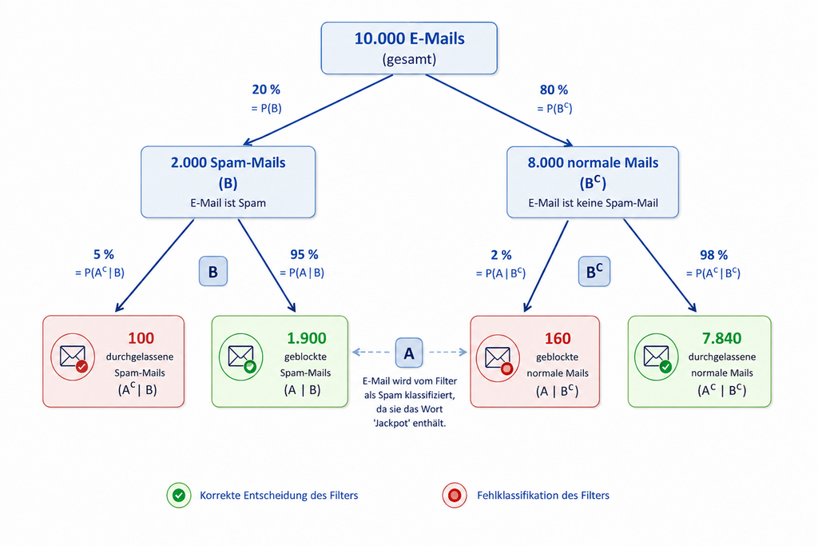

Auf der ersten Ebene unterscheiden wir zwischen Spam (Ereignis $B$ ) und kein Spam (Ereignis $B^\complement$ ). Von den $10000$ E-Mails sind also $2000$ ($=20\%$ von $10000$) Spam.

Auf der zweiten Ebene verwenden wir die bedingten Wahrscheinlichkeiten aus unserer Tabelle. Wenn die E-Mail Spam ist ( $\vert\, B$ , also bedingt auf Ereignis $B$ ), enthält sie mit einer Wahrscheinlichkeit von $95\%$ das Wort ‘Jackpot’ (Ereignis $A$ ). Von den $2000$ Spam-Mails werden also $2000\cdot 0.95=1900$ E-Mails geblockt. Ganz analog werden $2000\cdot 0.05=100$ E-Mails von unserem Spam-Filter durchgelassen. Die rechte Seite des Baums behandelt man ganz ähnlich: von den $8000$ normalen E-Mails (Ereignis $B^\complement$ ) enthalten $98\%$ nicht das Wort ‘Jackpot’ und werden deshalb durchgelassen - das sind insgesamt $8000\cdot 0.98=7840$ E-Mails. Die verbleibenden $160$ E-Mails werden geblockt.

Das Ereignis $A$ enthält insgesamt $2060$ E-Mails. Es setzt sich zusammen aus den geblockten Spam-Mails ($1900$) und den geblockten normalen E-Mails ($160$). Hier können wir dann auch direkt $P(B\vert A)$ ablesen, es gilt nämlich:

$$P(B\vert A)=\frac{P(A\cap
B)}{P(A)}=\frac{1900/10000}{(1900+160)/10000}=\frac{1900}{2060}=0.922\,.$$
Der Trick hierbei ist die **Pfadmultiplikationsregel**. Um die Zahlen auf der untersten Ebene zu erhalten, haben wir die Gesamtanzahl von $10000$ E-Mails sukzessive mit den Wahrscheinlichkeiten $P(B)$ oder $P(B^\complement)$ und dann den entsprechenden bedingten Wahrscheinlichkeiten ($P(A\vert B)$ oder $P(A^\complement \vert B)$ bzw. $P(A\vert B^\complement)$ oder $P(A^\complement \vert B^\complement)$) multipliziert. Es gilt aber:
$$P(A\vert B)
\cdot P(B) =\frac{P(A\cap B)}{P(B)}\cdot P(B)=P(A\cap B)\,,$$
so dass diese Produkte gerade die Wahrscheinlichkeiten der Schnittmengen (von links nach rechts: $A^\complement \cap B$, $A \cap B$, $A \cap B^\complement$, $A^\complement \cap B^\complement$) ergeben. Deshalb können wir einfach ablesen (beachte: wir haben insgesamt $10000$ Emails):
$$P(A\cap B)=\frac{1900}{10000}\,,$$
und es gilt
$$P(A)=P(A\cap B)+P(A\cap
B^\complement)=\frac{1900}{10000}+\frac{160}{10000}\,.$$
Der Quotient dieser beiden Wahrscheinlichkeiten ist dann gerade die gesuchte bedingte Wahrscheinlichkeit $P(B\vert A)$, die mit unserem vorherigen Ergebnis übereinstimmt.